# Att rita grafer (plot)

De förslag på hur man ritar grafer som framförs här grundar sig på matplotlib.pyplot. Det kallas att plotta med Pyplot. Det ger snabbt resultat. Om man vill kontrollera ritandet mer i detalj så rekommenderar python.org att man använder det objekt orienterade skrivsättet i stället. Vi behandlar inte det här utan det kommer att finnas på en annan plats.

Här på jupyter ritas graferna på ett visst sätt med de inställningar som finns. Ritar du dem på replit.com eller på din egen dator kommer det att se annorlunda ut.

## Mallen

För att kunna rita grafer måste vi importera moduler. Vi har konstaterat att vi i grundutförandet inte kan göra `sin(1.2)`. Men om vi importerade math-modulen så gick det bra. Men för att kunna rita önskar vi oss mer. För att kunna rita för hand behöver vi en värdetabell och det behöver python också. Så vi måste ha en lista med x-värden tex. `Lx=[0.1,0.2,0.3,0.4]`. Detta kan `range()` hjälpa oss med. Men sedan vill vi beräkna sinusvärden för alla talen i listan. Då kan man göra en loop med `sin(Lx[i])`. Men man har fixat detta problem och lagt det i en modul så man kan direkt skriva sinus av en lista och få sinus för alla elementen i listan. Kommandot `sin(Lx)` är tillåtet och python gör en ny lista med alla sinusvärdena. Vi behöver en modul som heter numpy (numerical python). Vi testar detta kommando först innan vi behandlar hur värdetabellen ska ritas.

Man skulle kunna säga att det fungerar så här:

$$ \begin{align*} \sin\left(Lx\right) & =\sin\left(\left[0.1,0.2,0.3,0.4\right]\right)=\left[\sin\left(0.1\right),\,\sin\left(0.2\right),\,\sin\left(0.3\right),\,\sin\left(0.4\right)\right]=\\ & \left[0.0998,\,0.1987,\,0.2955,\,0.3894\right]=Ly \end{align*} $$

```python
import numpy as np

Lx = [0.1,0.2,0.3,0.4]
Ly = np.sin(Lx)
print(Lx,Ly) # Både Lx och Ly är listor
```

```
[0.1, 0.2, 0.3, 0.4] [0.09983342 0.19866933 0.29552021 0.38941834]
```

Man har gjort det ännu smidigare genom ett kommando man infört. De heter `linspace()`. linspace skapar en datatyp som heter array (används för vektorer). array har inte samma egenskaper som en lista. Skillnaden syns om man beräknar tex. `2*L` där L är en lista respektive en array. Om L är en lista gäller konkatenering. Om L är en array gäller att varje element multipliceras med 2.

Skilj på linspace och lista.

```python
import numpy as np

L1 = np.linspace(0,4,5)  # array, (start, stopp, antal)
L2 = [0,1,2,3,4]  # Lista

print(L1,L2)
print("\n")
print(2*L1, type(L1))  # array; varje element multipliceras med 2
print(2*L2, type(L2))  # lista; skapar 2 listor som konkateneras
```

```
[0. 1. 2. 3. 4.] [0, 1, 2, 3, 4]


[0. 2. 4. 6. 8.] <class 'numpy.ndarray'>
[0, 1, 2, 3, 4, 0, 1, 2, 3, 4] <class 'list'>
```

ndarray står för n-dimensional array, en datatyp.

Skrivsättet blir väldigt suggestivt. Man kan göra samma sak med flera olika tal på samma gång.

```python
import numpy as np

x=np.linspace(-2*np.pi,2*np.pi,10)
print(x)
```

```
[-6.28318531 -4.88692191 -3.4906585  -2.0943951  -0.6981317   0.6981317
  2.0943951   3.4906585   4.88692191  6.28318531]
```

Kommandot `linspace()` ska ha start och stopp och antal värden `linspace(start, stopp, num)`. I detta fall har jag använt intervallet från $-2\pi$ till $2\pi$. Allra sist står antalet (`num`) tal som jag vill ha. I detta fall 10 stycken.

Observera att stopp ingår, se nedan.

```python
import numpy as np

x=np.linspace(-2,2,10)
print(x)
```

```
[-2.         -1.55555556 -1.11111111 -0.66666667 -0.22222222  0.22222222
  0.66666667  1.11111111  1.55555556  2.        ]
```

Vi gör en värdetabell, både x och y

```python
import numpy as np

x = np.linspace(-2*np.pi,2*np.pi,10) # x är en array
print("x-värden",x)
y = np.sin(x) # nästan samma skrivsätt som i matematiken
print("y-värden",y)
```

```
x-värden [-6.28318531 -4.88692191 -3.4906585  -2.0943951  -0.6981317   0.6981317
  2.0943951   3.4906585   4.88692191  6.28318531]
y-värden [ 2.44929360e-16  9.84807753e-01  3.42020143e-01 -8.66025404e-01
 -6.42787610e-01  6.42787610e-01  8.66025404e-01 -3.42020143e-01
 -9.84807753e-01 -2.44929360e-16]
```

Nu har vi vår värdetabell klar. Nu behöver vi ladda en modul som sköter om själva plottandet.

Modulen som behöver importeras, heter `matplotlib.pyplot`. De nya kommandona framgår av koden.

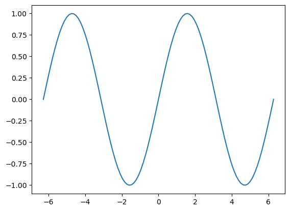

```python
# Mall för enkel plottning

import matplotlib.pyplot as plt
import numpy as np

# Värdetabell
x = np.linspace(-2*np.pi, 2*np.pi, 100)
y = np.sin(x)

#Nu ritar vi!
plt.plot(x,y)
plt.show()
```

Python justerar själv koordinatsystemet om man inte säger något, dock finns det kommando för det också.

Om du skrivit raderna i en textfil, tex. på replit.com måste du även ange kommandot `plt.show()` annars får du ingen graf att själv titta på. (jupyter klarar sig utan den, men lägger till en rad i utskriften om den inte är med)

Följden av kommandon (import, x=, y=, plot...) används ofta som en mall, sedan är det bara att fylla i och ändra efter behov.

## Utsmyckning

Naturligtvis kan man själv ändra koordinatsystem, rita flera kurvor i samma diagram, ändra färger på kurvorna, lägga in förklarande text osv.

Exempel följer. Observera att i anropet på funktionen plt.plot() används nyckelord, vilket vi behandlat i 2.4 om funktioner.

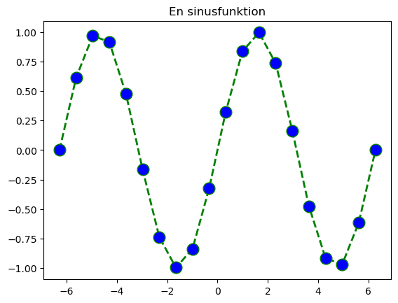

```python
import matplotlib.pyplot as plt
import numpy as np

# Värdetabell
x = np.linspace(-2*np.pi, 2*np.pi, 20)
y = np.sin(x)

# Rita med utsmyckning
plt.plot(x,y, color="green",
         linestyle='dashed',
         marker='o',
         markerfacecolor='blue',
         markersize=12,
         linewidth=2)

plt.title('En sinusfunktion')

plt.show()
```

Observera hur hela kommandot plot() är uppdelat på flera olika rader, det ökar läsbarheten. Det är tillåtet att göra så och python väntar på den avslutande högerparentesen.

Som du kanske inser från tidigare avsnitt så har flera av parametrarna (color, linestyle osv) egna default (förinställda) värden som används om du inte anger något. Vi har tex. anget att color ska ha värdet "green", men om vi inte skickar argumentet "green" så finns det ett förinställt värde som python använder.

Experimentera. Observera stavningen av färg, det är color inte colour. Observera också att det är strängar som ska anges så citattecken måste vara med.

På replit.com finns det möjlighet att spara figuren genom att klicka på en ikon i figuren. Men man kan också skriva till ett kommando för det `plt.savefig()`.

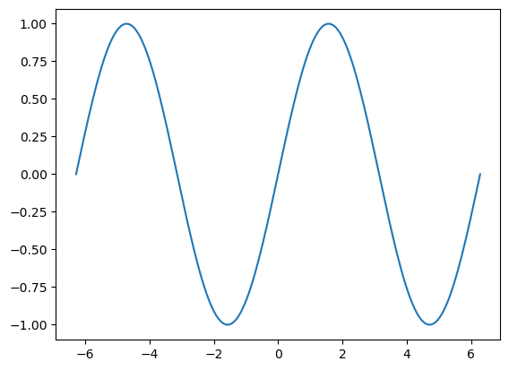

```python
import matplotlib.pyplot as plt
import numpy as np


x=np.linspace(-2*np.pi, 2*np.pi, 200)
y=np.sin(x)
plt.plot(x,y)

plt.savefig('plot.png')
plt.show()
```

På replit.com syns grafen till höger (i standardinställningen) och en fil med namnet plot.png skapas och läggs bland filerna till vänster där main.py ligger. Denna kan du sedan ladda ner. Flera olika bildformat fungerar.

## Två kurvor i samma graf

Vi har ritat endast en kurva i grafen, nu ritar vi 2.

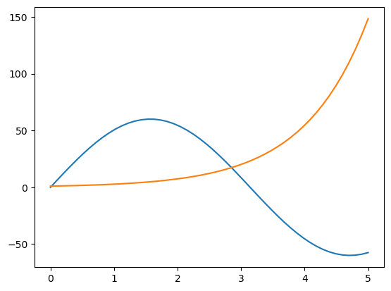

```python
import matplotlib.pyplot as plt
import numpy as np

# Kurva 1
x = np.linspace(0, 5, 50)
y = 60*np.sin(x)
plt.plot(x,y)

# Kurva 2
x = np.linspace(0, 5, 50)
y = np.exp(x)
plt.plot(x,y)

#Ritas i samma graf!

plt.show()
```

Vad är det som gör att det blir två kurvor i en graf och inte två grafer med en kurva i varje? Det som är signifikant är att kommandot plt.show() kommer efter att vi gett två kommandon plt.plot(). Om vi ger kommandot plt.show() omedelbart efter ett plt.plot() så får vi två grafer.

Se nedan för 2 åtskilda plottar. På jupyter visas båda plottarna direkt. På replit.com måste du stänga den första för att se den andra. Om du sitter vid en vanlig terminal på en dator måste du också stänga den första grafen för att få den andra. Beroende på val av IDE kan det kanske variera.

I vilket fall så kan man alltid spara dem (plt.savefig("namn"); innan plt.show()) en och en.

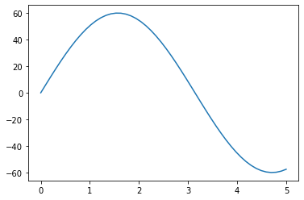

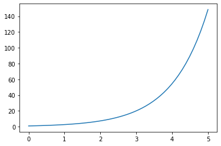

```python
import matplotlib.pyplot as plt
import numpy as np

# Kurva 1
x = np.linspace(0, 5, 50)
y = 60*np.sin(x)
plt.plot(x,y)
plt.show()

# Kurva 2
x = np.linspace(0, 5, 50)
y = np.exp(x)
plt.plot(x,y)
plt.show()
```

## Staplade grafer

För att kunna rita så kallade subplots behövs en styrning av var graferna ska placeras. Man tänker i rader och kolumner. Kommandot är `subplot(nrows, ncols, index)`. `nrows` anger antalet rader och `ncols` anger antalet kolumner. Index anger var grafen ska ritas. Index går från vänster till höger och uppifrån och ner.

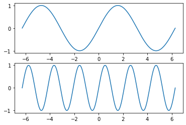

```python
"""
Rita båda funktionerna i två olika grafer samtidigt

subplot(nrows, ncols, index)

"""

import matplotlib.pyplot as plt
import numpy as np


x = np.linspace(-2*np.pi, 2*np.pi, 200)
y = np.sin(x)
plt.subplot(2,1,1) # Två rader, en kolumn, index 1
plt.plot(x,y)


x = np.linspace(-2*np.pi, 2*np.pi, 200)
y = np.sin(3*x)
plt.subplot(2,1,2) # index 2
plt.plot(x,y)


plt.savefig('plot2.png')
plt.show()
```

Vi gör en 2 gånger 2 och plottar i index 1 och 4. Index 2 och 3 är då tomma.

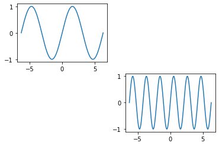

```python
"""
Rita båda funktionerna i två olika grafer samtidigt

subplot(nrows, ncols, index)

"""

import matplotlib.pyplot as plt
import numpy as np


x = np.linspace(-2*np.pi, 2*np.pi, 200)
y = np.sin(x)
plt.subplot(2,2,1) # Två rader, två kolumneer, index 1
plt.plot(x,y)


x = np.linspace(-2*np.pi, 2*np.pi, 200)
y = np.sin(3*x)
plt.subplot(2,2,4) # index 4
plt.plot(x,y)


plt.savefig('plot2.png')
plt.show()
```

## Mätdata

Vi använder mätdata från ett experiment och skriver den i listor. Axlarna bestämmer vi själva denna gång: `plt.axis([0,6,0,20])` anger att x-axeln går från 0 till 6 och y-axeln från 0 till 20. Argumentet är en lista.

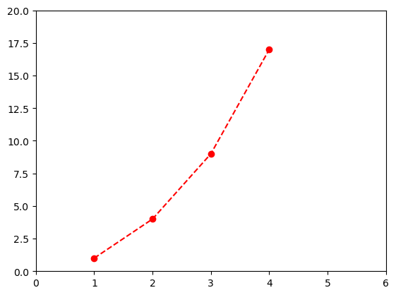

```python
import matplotlib.pyplot as plt
import numpy as np

# Mätdata som skrivits in i listor
x = [1,2,3,4]
y = [1,4,9,17]
plt.axis([0,6,0,20]) # Observera att det är en lista.

plt.plot(x, y, 'ro--')  # röd cirkel, streckad kurva

plt.show()
```

Vill vi inte ha de räta linjerna mellan datapunkterna så heter commandot `plt.scatter(x,y)`. Man kan också utelämna typen av kurva `plt.plot(x, y, 'ro')` så att `--` saknas.

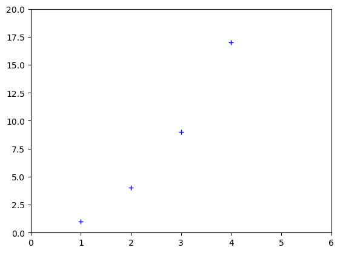

```python
import matplotlib.pyplot as plt
import numpy as np

# Mätdata som skrivits in i listor
x = [1,2,3,4]
y = [1,4,9,17]
plt.axis([0,6,0,20])

# Nytt kommando! Två alternativ.
# plt.scatter(x, y)

# Eller detta
plt.plot(x, y, 'b+') # blue för blå, markör är + tecken

plt.show()
```

## Teckenförklaring (legend)

Om flera kurvor ritas kan det vara bra att ge information om dem. I detta fall låter vi python bestämma var det finns plats. Kommandona som används är:

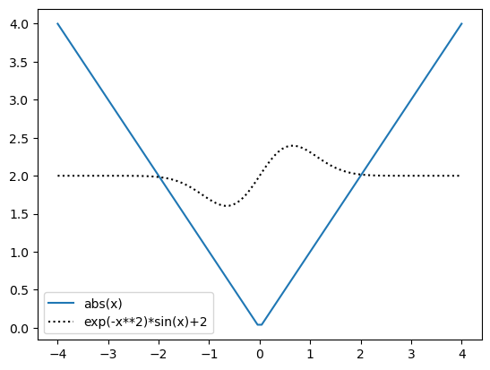

```python
import numpy as np
import matplotlib.pyplot as plt

# abs(x)
x = np.linspace(-4, 4, 100)
y = abs(x)
plt.plot(x,y, label='abs(x)')  # Denna kurva får etiketten abs(x)


# exp(-x**2)*sin(x)
x = np.linspace(-4, 4, 100)
y = np.exp(-x**2)*np.sin(x)+2
plt.plot(x,y,'k:', label='exp(-x**2)*sin(x)+2')  # svart (black) och pricklinje (dotted) linje


plt.legend(loc='best', fontsize='medium')

plt.show()
#savefig('plot.png')
```

## Histogram

Även histogram kan ritas med matplot.pyplot.

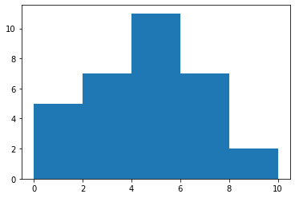

```python
import matplotlib.pyplot as plt

# Data i lista
x = [1,1,1,1,1,2,2,2,2,2,3,3,
4,4,4,4,5,5,5,5,5,5,5,6,6,6,6,7,7,7,8,8]


# Kommandot för att plotta histogram
plt.hist(x, [0,2,4,6,8,10])

# De vanliga
plt.savefig("plot.png")
plt.show()
```

Kommentar angående `plt.hist(x, [0,2,4,6,8,10])`

Argumentet består av 2 listor. Datamängden ska finnas i listan x. Listan efter x är listan som anger var gränserna för de olika binen ska gå, de olika grupperna. Intervallet from. 0 till 2 är första binet; alltså inklusive 0 och exklusive 2. För det sista intervallet 8 till 10 gäller dock inklusive för båda gränserna. Vi ser från datamängden att det finns inga 0:or och 5 stycken 1:or vilket ger en stapel med höjden 5 för intervallet 0 till 2; vi ser vidare att det finns 5 st 2:or och 2 st 3:or så 7 blir höjden för intervallet 2 till 4.

Vi kan också bara ange antalet intervall vi önskar och lämna resten till python som då konstruerar intervall som är lika stora. Anger vi inget intervall så är det förinställt 10 stycken.

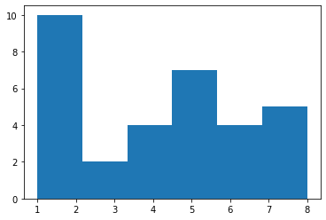

```python
import matplotlib.pyplot as plt

# Data
x = [1,1,1,1,1,2,2,2,2,2,3,3,
4,4,4,4,5,5,5,5,5,5,5,6,6,6,6,7,7,7,8,8]


# Kommandot för att plotta histogram
plt.hist(x, 6)

# De vanliga
plt.savefig("plot.png")
plt.show()
```

`plt.hist(x,6)` är ett anrop precis som när vi skriver en def, den returnerar värden i något som heter en tuple och den fungerar ungefär som en lista. Detta innebär att vi kan skriva ut värdena som används för att konstruera grafen numeriskt.

```
Antalet i varje intervall [10.  2.  4.  7.  4.  5.]
Binens gränser [1.         2.16666667 3.33333333 4.5        5.66666667 6.83333333
 8.        ]
```

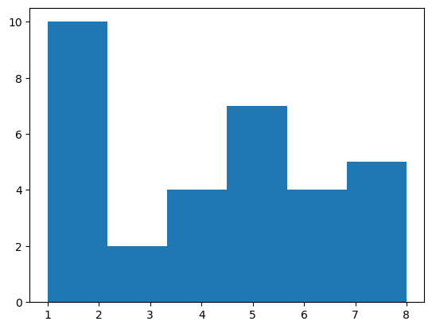

```python
import matplotlib.pyplot as plt

# Data
x = [1,1,1,1,1,2,2,2,2,2,3,3,
4,4,4,4,5,5,5,5,5,5,5,6,6,6,6,7,7,7,8,8]


# Kommandot för att plotta histogram, nu med
# return-värdena så vi kan skriva ut dem
n,bins,patches = plt.hist(x, 6)

print("Antalet i varje intervall", n)
print("Binens gränser", bins)
# patches bryr vi oss inte om


# De vanliga
plt.savefig("plot.png")
plt.show()
```

## Uppgifter

**Uppgift 1**

Rita en graf över följande mätdata.

| Tid (s) | Läge (m) |
| --- | --- |
| 0.1 | 0.00 |
| 0.2 | 0.01 |
| 0.3 | 0.03 |
| 0.4 | 0.06 |
| 0.5 | 0.11 |
| 0.6 | 0.18 |
| 0.7 | 0.26 |
| 0.8 | 0.36 |
| 0.9 | 0.45 |
| 1 | 0.54 |
| 1.1 | 0.60 |
| 1.2 | 0.63 |
| 1.3 | 0.59 |
| 1.4 | 0.47 |
| 1.5 | 0.24 |

Lösningsexempel

**Uppgift 2**

Rita $y=(x-3)^2$ och $y=(x-5)^2$ och $y=(x+5)^2$ i samma graf. Gränserna i x-led ska vara -10 och 10

Lösningsexempel

**Uppgift 3**

Rita sin(x) och cos(x) i samma graf. Gränserna ska vara 0 och 2$\pi$.

Lösningsexempel

**Uppgift 4**

Vad är det för skillnad mellan kommandona range(), arange() och linspace()?

Lösningsexempel

**Uppgift 5**

Konstruera ett histogram ur följande data:

x=[1,1,2,2,1,1,2,2,5,5,6,6,4,4,4,4,5, 5,5,6,6,6,6,7,1,3,2,5,3,7,8,4,4]

med bin/intervall av storleken 2 med start från 1.

Lösningsexempel

**Uppgift 6**

I ett experiment erhålls följande data i en lista:

Lx=[1,3,11,24]

Ly=[190,1700,24600,115700]

Det antas utifrån en teori att kurvan som punkterna ungefärligen ligger på ska vara en andragradsfunktion på formen $y=Ax^2$ (ingen x term eller konstant således). Använd datapunkterna för att anpassa funktionen. Kurvan antas dock stämma lite dåligt för första punkten så den kan inte användas för anpassning. Plotta sedan data som + och den anpassade kurvan som en jämn kurva. Använd teckenförklaring (eng. legend).

Lösningsexempel

**Uppgift 7**

Plotta följande funktioner, välj rimliga axlar.

a) $f_1(x)=\left| x \right|$

b) $f_2(x)=e^{-x}\sin(x)$

c) $f_3(x)=\frac{\sin\left(x\right)}{x}$

d) $f_4(x)=\sin\left(1/x\right)$

Lösningsexempel

**Uppgift 8**

Rita sin(x). Rita i samma figur Maclaurin polynomen med gradtal 1, 3 och 5, se nedan. Ju högre gradtal man tar med desto bättre ansluter polynomet till sinusfunktionen kring x=0. Gör graferna så att de tydligt kan skiljas åt. Justera axlar, använd färger och olika linjer. Ingen förklaring behöver ges i grafen (ingen ’legend’).

$$ \sin\left(x\right)=x-\frac{x^{3}}{3!}+\frac{x^{5}}{5!} $$

Lösningsexempel